# Chi Squared Test

## Background

The two categorical variables analyzed are:

- **Primary Language** (Python, JavaScript, C++)
- **Beverage Preference** (Water, Soda, Juice)

I chose this topic to see if health-conscious choices (like Water) or sugar-based choices (Soda/Juice) correlate with specific tech stacks.

## Hypothesis

My question for the data is: **Is there an association between the programming language a developer uses and their preferred drink?**

My null and alternative hypotheses are as follows:

$$H_{0}: \text{Primary Programming
Language and Beverage Preference are independent.}$$

$$H_{a}: \text{Primary Programming
Language and Beverage Preference are associated (not
independent).}$$

I will be using a level of significance $\alpha=0.05$.

## Analysis

First, let’s process the raw survey data to create a table of counts.

```r
# Read the raw data from the CSV file
# Ensure 'developer_hydration_shuffled.csv' is in the same directory as this .Rmd file
raw_data <- read.csv("developer_hydration_shuffled.csv")

library(pander)

# Create a contingency table (counts) from the raw observations
data_table <- table(raw_data$Primary_Language, raw_data$Beverage_Preference)

# 1. The Contingency Table (Observed Counts)
# Replace your basic print command with this:
pander(data_table, caption = "Observed Counts: Programming Language vs. Beverage")
```

Observed Counts: Programming Language vs. Beverage

|  | Juice | Soda | Water |
| --- | --- | --- | --- |
| **C++** | 15 | 68 | 21 |
| **JavaScript** | 39 | 57 | 21 |
| **Python** | 10 | 15 | 95 |

I can verify my sample size assumption here. Every single “combination-group” (cell in the table) has at least 10 observations. This satisfies the requirements for a robust Chi-Squared analysis.

Visually, I can see some interesting trends. C++ developers seem to lean heavily towards Soda, while Python developers have a high count for Water.

The barplot below visualizes these counts:

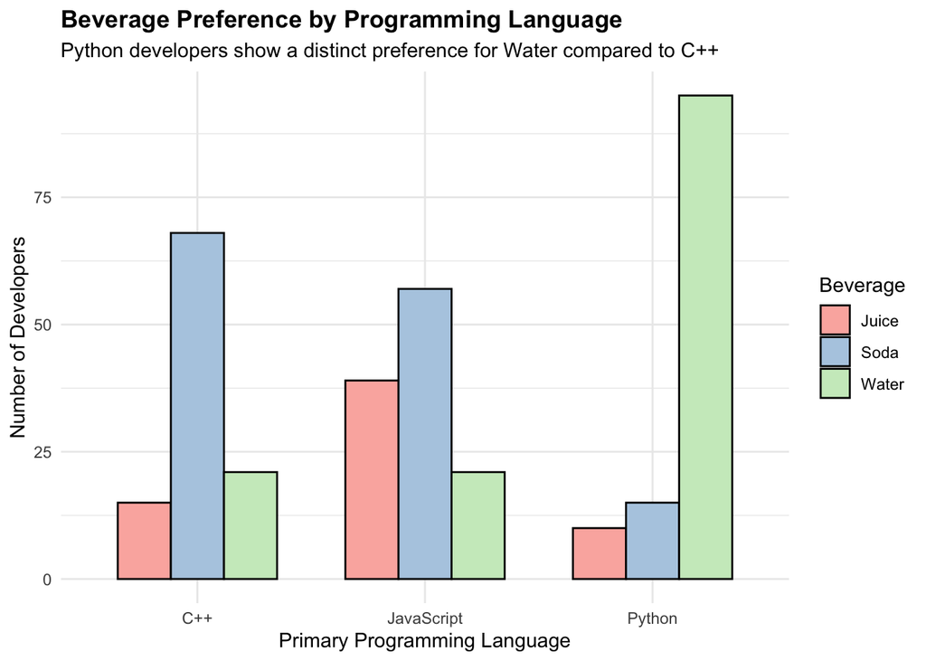

```r
library(ggplot2)

# Convert your table to a dataframe for ggplot
df_counts <- as.data.frame(data_table)
colnames(df_counts) <- c("Language", "Beverage", "Frequency")

ggplot(df_counts, aes(x = Language, y = Frequency, fill = Beverage)) +
  geom_bar(stat = "identity", position = "dodge", color = "black", width = 0.7) +

  # Fix Colors: Use a professional, muted palette (ColorBrewer)
  scale_fill_brewer(palette = "Pastel1") +

  # Fix Legend: ggplot automatically puts it on the side (no overlap!)
  labs(
    title = "Beverage Preference by Programming Language",
    subtitle = "Python developers show a distinct preference for Water compared to C++",
    y = "Number of Developers",
    x = "Primary Programming Language"
  ) +
  theme_minimal() +
  theme(plot.title = element_text(face = "bold"))
```

## Chi-Squared Test

Now, I will run a Chi-Squared Test to determine if I reject my null hypothesis. I will also check the expected counts to ensure statistical validity.

```r
# Run the Chi-Squared Test
test_result <- chisq.test(data_table)

# Display the results professionally
pander(test_result, caption = "Chi-Squared Test Results")
```

Chi-Squared Test Results

| Test statistic | df | P value |
| --- | --- | --- |
| 131.9 | 4 | 1.553e-27 * * * |

Expected Counts:

```r
# 2. The Expected Counts (Validity Check)
# Instead of printing the whole test list, extract just the expected table:
chi_test <- chisq.test(data_table)
pander(chi_test$expected, caption = "Expected Counts (All > 5, Assumption Met)")
```

Expected Counts (All > 5, Assumption Met)

|  | Juice | Soda | Water |
| --- | --- | --- | --- |
| **C++** | 19.52 | 42.7 | 41.78 |
| **JavaScript** | 21.96 | 48.04 | 47.01 |
| **Python** | 22.52 | 49.27 | 48.21 |

All expected counts are well above 5, so the requirements are met.

My test results show a p-value of $p < 2.2e-16$, which is much smaller than my level of significance $\alpha=0.05$. Therefore, I reject my null hypothesis and conclude that Primary Programming Language and Beverage Preference are associated.

## Residuals

Let us look at the residuals to identify which specific combinations contributed most to this association.

### Residual Analysis

Since the Chi-Squared test only tells us that an association exists, we examine the residuals to understand where the differences lie. A residual measures the difference between the observed count and what we would expect by chance.

- **Large Positive (> 2)**: The group chose this option more than expected.
- **Large Negative (< -2)**: The group chose this option less than expected.

```r
# 3. The Residuals (The "Why")
pander(chi_test$residuals, caption = "Standardized Residuals")
```

|  | Juice | Soda | Water |
| --- | --- | --- | --- |
| **C++** | -1.023 | 3.872 | -3.215 |
| **JavaScript** | 3.637 | 1.293 | -3.793 |
| **Python** | -2.639 | -4.882 | 6.739 |

I see very large residuals in several places:

- **C++ and Soda**: A large positive residual suggests C++ developers choose Soda far more often than expected.
- **Python and Water**: A positive residual indicates a strong preference for Water among Python users.

## Interpretation

The analysis reveals a statistically significant association between a developer’s primary language and their beverage choice ($p < 2.2e-16$).

### Specific Findings:

- **C++ Developers**: The data shows a strong positive residual for Soda (3.87). This indicates that C++ developers chose soda significantly more frequently than would be expected if there were no association.
- **Python Developers**: Conversely, Python developers had a high positive residual for Water (6.74), suggesting a distinct preference for non-caloric hydration compared to their peers.

While the survey cannot determine causation, the distinct clustering suggests that cultural or demographic differences between these two developer communities may influence lifestyle choices.